# Reproducible Research - Course Project 1

## Data info

Data set activity.csv from https://d396qusza40orc.cloudfront.net/repdata%2Fdata%2Factivity.zip

The variables included in this dataset are:

- steps: Number of steps taking in a 5-minute interval (missing values are coded as NA)
- date: The date on which the measurement was taken in YYYY-MM-DD format
- interval: Identifier for the 5-minute interval in which measurement was taken

The dataset is stored in a comma-separated-value (CSV) file and there are a total of 17,568 observations in this dataset.

## Assignment Results

1. Code for reading in the dataset and/or processing the data

```r
#load necessary libraries for assignment
library("ggplot2")
library("dplyr")
#set directory and read file
setwd("C://Users//WongD//Documents//R//R-3.3.1//r programming//reproducible research week 2")
activity<-read.csv("activity.csv", header=TRUE)
```

2. Histogram of the total number of steps taken each day

```r
#groups all intervals and steps by date
daily<-group_by(activity, date)
daily<-summarise_each(daily, funs(sum))
# data check
head(daily)
```

```
## # A tibble: 6 × 3
##         date steps interval
##       <fctr> <int>    <int>
## 1 2012-10-01    NA   339120
## 2 2012-10-02   126   339120
## 3 2012-10-03 11352   339120
## 4 2012-10-04 12116   339120
## 5 2012-10-05 13294   339120
## 6 2012-10-06 15420   339120
```

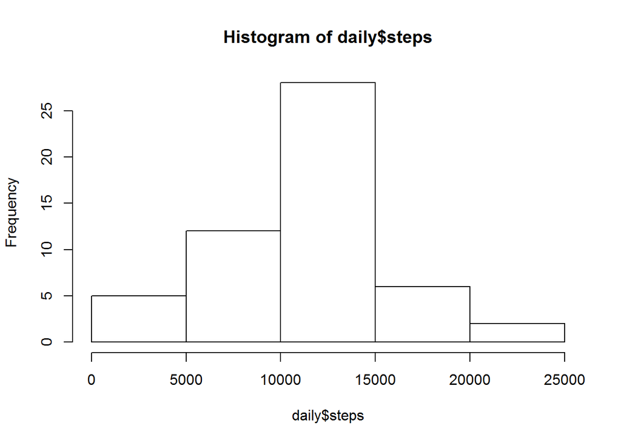

```r
# output 2
hist(daily$steps)
```

```r
##alternate format using ggplot
##ggplot(data=daily, aes(daily$steps))+geom_histogram()
```

3. Mean and median number of steps taken each day

```r
#various ways of calculating mean and median
daily_mean<-mean(daily$steps, na.rm=TRUE)
daily_median<-median(daily$steps, na.rm=TRUE)
summary(daily)
```

```
##          date        steps          interval
##  2012-10-01: 1   Min.   :   41   Min.   :339120
##  2012-10-02: 1   1st Qu.: 8841   1st Qu.:339120
##  2012-10-03: 1   Median :10765   Median :339120
##  2012-10-04: 1   Mean   :10766   Mean   :339120
##  2012-10-05: 1   3rd Qu.:13294   3rd Qu.:339120
##  2012-10-06: 1   Max.   :21194   Max.   :339120
##  (Other)   :55   NA's   :8
```

4. Time series plot of the average number of steps taken

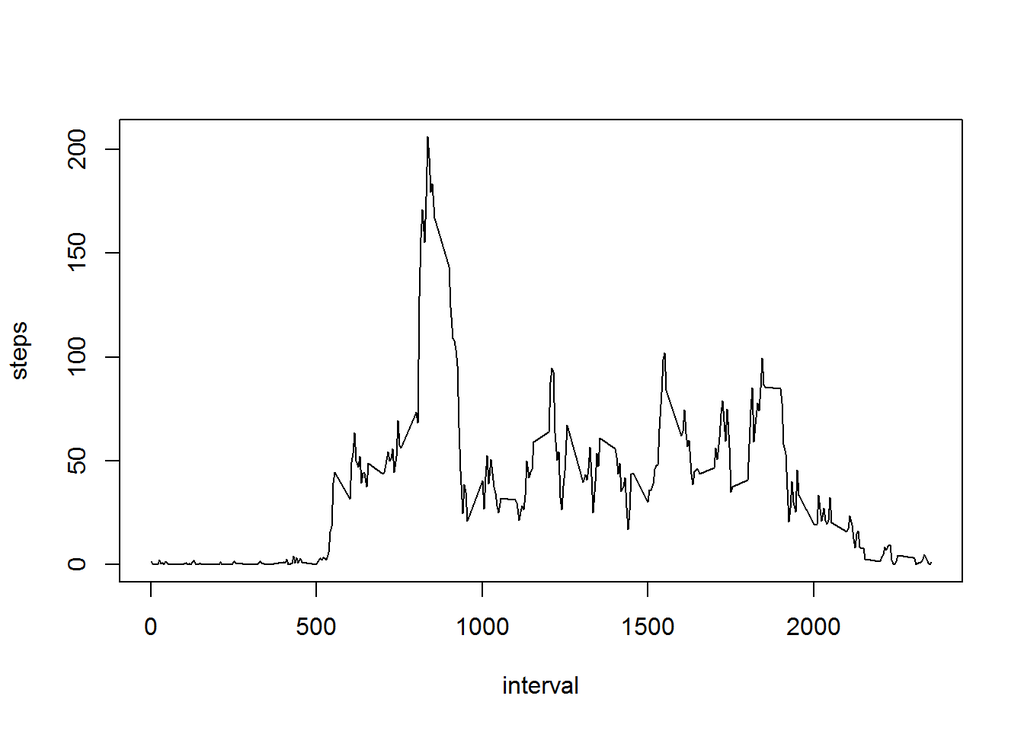

```r
##transforms data so it gets steps mean by interval
interval5<-aggregate(steps ~ interval, activity, FUN = "mean")
##time series plot
with(interval5, plot(interval, steps, type='l'))
```

```r
##stores max steps
max_steps_row <- which.max(interval5$steps)
```

5. The 5-minute interval that, on average, contains the maximum number of steps

max step interval = 835 max step = 206.1698113

6. Code to describe and show a strategy for imputing missing data

Strategy taken is to assume all NAs to be equivalent of mean of the interval. For example, if date x, interval y has step value of NA, then step value of NA would be replaced with average steps of interval y.

```r
imputed<-activity

## loop to replace any na value in steps
for (i in 1:nrow(imputed)) {
  if (is.na(imputed$steps[i])) {
    replacement<-imputed$interval[i]
    imputed$steps[i]<-interval5$steps[interval5$interval==replacement]
  }
}
```

7. Histogram of the total number of steps taken each day after missing values are imputed

```r
#groups all intervals and steps by date, using imputed dataset which has replaced NAs
imputed_daily<-group_by(imputed, date)
imputed_daily<-summarise_each(imputed_daily, funs(sum))
head(imputed_daily)
```

```
## # A tibble: 6 × 3
##         date    steps interval
##       <fctr>    <dbl>    <int>
## 1 2012-10-01 10766.19   339120
## 2 2012-10-02   126.00   339120
## 3 2012-10-03 11352.00   339120
## 4 2012-10-04 12116.00   339120
## 5 2012-10-05 13294.00   339120
## 6 2012-10-06 15420.00   339120
```

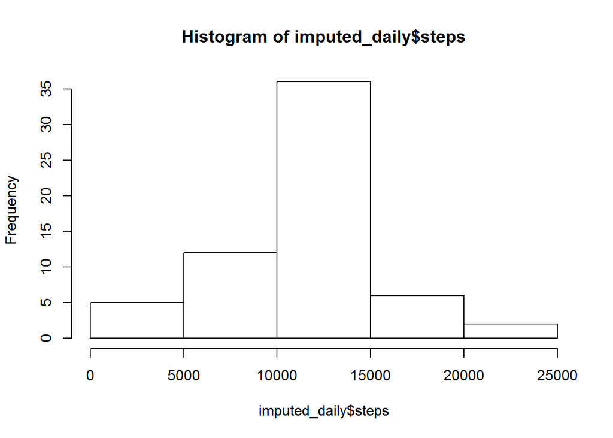

```r
hist(imputed_daily$steps)
```

8. Panel plot comparing the average number of steps taken per 5-minute interval across weekdays and weekends

```r
#create empty variable for now to store date
imputed$date <- as.Date(imputed$date)
#create a vector of weekdays
weekdays1 <- c('Monday', 'Tuesday', 'Wednesday', 'Thursday', 'Friday')
#Use `%in%` and `weekdays` to create a logical vector
#convert to `factor` and specify the `levels/labels`
imputed$wDay <- factor((weekdays(imputed$date) %in% weekdays1),levels=c(FALSE, TRUE), labels=c('weekend', 'weekday'))

#split data by weekend and weekdays
weekend_result<- subset(imputed, wDay=="weekend")
head(weekend_result)
```

```
##      steps       date interval    wDay
## 1441     0 2012-10-06        0 weekend
## 1442     0 2012-10-06        5 weekend
## 1443     0 2012-10-06       10 weekend
## 1444     0 2012-10-06       15 weekend
## 1445     0 2012-10-06       20 weekend
## 1446     0 2012-10-06       25 weekend
```

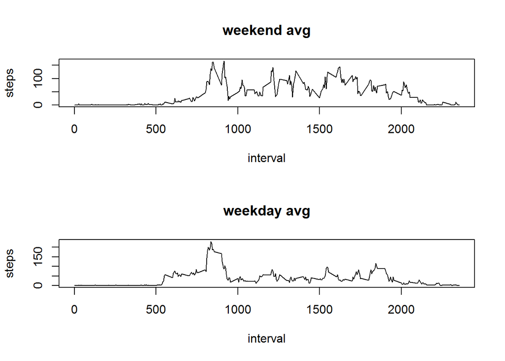

```r
weekday_result<- subset(imputed, wDay=="weekday")

#once data is split by weekend and weekdays, aggregate steps by interval and graph the results
par(mfrow=c(2,1))
weekend_interval<-aggregate(steps ~ interval, weekend_result, FUN = "mean")
with(weekend_interval, plot(interval, steps, type='l', main="weekend avg"))

weekday_interval<-aggregate(steps ~ interval, weekday_result, FUN = "mean")
with(weekday_interval, plot(interval, steps, type='l', main="weekday avg"))
```

9. All of the R code needed to reproduce the results (numbers, plots, etc.) in the report